# green space EDA 2

Objectives:

- personal interest in the topic
- green gym
- covid experience

https://blogs.bmj.com/bmj/2020/07/03/covid-19-has-highlighted-the-inadequate-and-unequal-access-to-high-quality-green-spaces/ https://www.weforum.org/agenda/2020/08/parks-green-spaces-mental-health-access-equality/

- Develop

Scale of analysis: Local Authority District (the finest geographic granularity available for all datasets) Geographic scope: England (case data at MSOA level available for England only)

## 1. Import and tidy data sources

### 1.1. Access to private green space (gardens)

The ONS (Office for National Statistics) provides [data on access to private green space](https://www.ons.gov.uk/economy/environmentalaccounts/datasets/accesstogardensandpublicgreenspaceingreatbritain) (i.e. access to gardens) for each Local Authority District in Great Britain. Here I am using the most recent April 2020 edition of the data. I quickly, manually edited the ONS excel file to make it easier use the `read_excel` function for data import. Given it is unlikely that the ONS data will be updated during the course of this analysis, it was preferable to go for the quicker manual process than investing time in a re-producible programmatic approach.

```r
gardens <- read_excel("./Data/osprivateoutdoorspacereferencetables.xlsx", sheet = "LAD gardens_2")
gardens %>%
  sample_n_from_df(10)
```

| Country code | Country name | Region code | Region name | LAD code | LAD name | H_Address count | H_Adress with private outdoor space count | H_Private outdoor space total area (m2) | H_Percentage of adresses with private outdoor space | H_Average size of private outdoor space (m2) | H_Median size of private outdoor space (m2) | F_Address count | F_Adress with private outdoor space count | F_Private outdoor space total area (m2) | F_Private outdoor space count | F_Percentage of adresses with private outdoor space | F_Average size of private outdoor space (m2) | F_Average number of flats sharing a garden | T_Address count | T_Adress with private outdoor space count | T_Private outdoor space total area (m2) | T_Percentage of adresses with private outdoor space | T_Average size of private outdoor space (m2) |
| --- | --- | --- | --- | --- | --- | --- | --- | --- | --- | --- | --- | --- | --- | --- | --- | --- | --- | --- | --- | --- | --- | --- | --- |
| E92000001 | England | E12000008 | South East | E07000224 | Arun | 56624 | 55303 | 18317114 | 0.977 | 331.2 | 220.2 | 17784 | 13175 | 1413153.1 | 3757 | 0.741 | 376.1 | 3.5 | 74408 | 68478 | 19730267 | 0.920 | 334.1 |
| E92000001 | England | E12000009 | South West | E07000044 | South Hams | 36542 | 33501 | 18909857 | 0.917 | 564.5 | 269.9 | 8130 | 5773 | 1856182.8 | 2429 | 0.710 | 764.2 | 2.4 | 44672 | 39274 | 20766040 | 0.879 | 578.0 |
| E92000001 | England | E12000008 | South East | E07000215 | Tandridge | 27677 | 26708 | 21427561 | 0.965 | 802.3 | 373.4 | 9198 | 6243 | 1713871.1 | 1960 | 0.679 | 874.4 | 3.2 | 36875 | 32951 | 23141432 | 0.894 | 807.2 |
| W92000004 | Wales | W08000001 | Wales | W06000011 | Swansea | 91916 | 89359 | 24955130 | 0.972 | 279.3 | 193.7 | 22112 | 11707 | 1145855.6 | 4055 | 0.529 | 282.6 | 2.9 | 114028 | 101066 | 26100986 | 0.886 | 279.4 |
| E92000001 | England | E12000003 | Yorkshire and The Humber | E08000032 | Bradford | 178663 | 168539 | 35453003 | 0.943 | 210.4 | 149.2 | 38413 | 20922 | 2003211.7 | 7793 | 0.545 | 257.1 | 2.7 | 217076 | 189461 | 37456215 | 0.873 | 212.4 |
| W92000004 | Wales | W08000001 | Wales | W06000019 | Blaenau Gwent | 28565 | 27878 | 4916354 | 0.976 | 176.4 | 112.7 | 4613 | 3371 | 344004.0 | 1419 | 0.731 | 242.4 | 2.4 | 33178 | 31249 | 5260358 | 0.942 | 179.6 |
| E92000001 | England | E12000004 | East Midlands | E07000141 | South Kesteven | 57792 | 55753 | 23140901 | 0.965 | 415.1 | 235.9 | 7027 | 5282 | 883026.1 | 1719 | 0.752 | 513.7 | 3.1 | 64819 | 61035 | 24023927 | 0.942 | 418.0 |
| E92000001 | England | E12000008 | South East | E07000084 | Basingstoke and Deane | 64144 | 62425 | 26216825 | 0.973 | 420.0 | 178.3 | 13713 | 9544 | 1257270.2 | 2364 | 0.696 | 531.8 | 4.0 | 77857 | 71969 | 27474095 | 0.924 | 424.1 |
| E92000001 | England | E12000009 | South West | E07000043 | North Devon | 36123 | 33512 | 16168315 | 0.928 | 482.5 | 237.3 | 10964 | 7956 | 2037013.7 | 3456 | 0.726 | 589.4 | 2.3 | 47087 | 41468 | 18205328 | 0.881 | 492.5 |
| E92000001 | England | E12000007 | London | E09000002 | Barking and Dagenham | 51235 | 50808 | 8606729 | 0.992 | 169.4 | 123.9 | 24742 | 13403 | 692718.6 | 3566 | 0.542 | 194.3 | 3.8 | 75977 | 64211 | 9299448 | 0.845 | 171.0 |

### 1.2. Access to public green space (parks)

```r
parks <-  read_excel("./Data/ospublicgreenspacereferencetables.xlsx", sheet = "LAD Parks only")
parks %>%
  sample_n_from_df(10)
```

| Country code | Country name | Region code | Region name | LAD code | LAD name | Average distance to nearest Park (m) | Average size of nearest Park (m2) | Average number of Parks within one km | Average combined size of Parks within 1km (m2) |
| --- | --- | --- | --- | --- | --- | --- | --- | --- | --- |
| E92000001 | England | E12000002 | North West | E07000120 | Hyndburn | 317.33 | 37151.47 | 4.78 | 189971.54 |
| E92000001 | England | E12000002 | North West | E08000009 | Trafford | 311.83 | 44335.20 | 5.17 | 200681.73 |
| E92000001 | England | E12000001 | North East | E08000021 | Newcastle upon Tyne | 264.00 | 84038.70 | 7.99 | 704535.08 |
| S92000003 | Scotland | S15000001 | Scotland | S12000050 | North Lanarkshire | 329.04 | 113314.96 | 4.73 | 634044.53 |
| E92000001 | England | E12000006 | East of England | E07000012 | South Cambridgeshire | 490.41 | 39789.33 | 1.74 | 71238.36 |
| E92000001 | England | E12000004 | East Midlands | E07000038 | North East Derbyshire | 315.65 | 133836.21 | 3.95 | 415949.98 |
| E92000001 | England | E12000009 | South West | E07000187 | Mendip | 483.73 | 34756.79 | 2.90 | 82967.51 |
| E92000001 | England | E12000006 | East of England | E07000203 | Mid Suffolk | 689.33 | 41816.47 | 1.60 | 94106.34 |
| E92000001 | England | E12000002 | North West | E07000028 | Carlisle | 375.25 | 81400.20 | 3.79 | 238504.91 |
| S92000003 | Scotland | S15000001 | Scotland | S12000017 | Highland | 1768.59 | 39233.18 | 2.97 | 91789.85 |

### 1.3. Covid cases

```r
# store the date the data was provided by cornavirus.data.gov.uk for use later on in a plot
data_date <- "2020-12-08"
covid_19_file_path <-  str_c("./Data/ltla_", data_date, ".csv")

covid_cases <- read_csv(covid_19_file_path)

covid_cases %>%
  sample_n_from_df(10)
```

| date | areaType | areaCode | areaName | newCasesBySpecimenDate | newCasesBySpecimenDateRollingRate | newCasesBySpecimenDateRollingSum |
| --- | --- | --- | --- | --- | --- | --- |
| 2020-11-12 | ltla | E07000026 | Allerdale | 41 | 197.4 | 193 |
| 2020-08-13 | ltla | E07000124 | Ribble Valley | 0 | 11.5 | 7 |
| 2020-07-19 | ltla | E07000092 | Rushmoor | 0 | 2.1 | 2 |
| 2020-01-15 | ltla | E07000139 | North Kesteven | NA | 0.0 | NA |
| 2020-05-02 | ltla | E07000035 | Derbyshire Dales | 8 | 63.6 | 46 |
| 2020-08-29 | ltla | E06000009 | Blackpool | 0 | 9.3 | 13 |
| 2020-04-26 | ltla | E09000031 | Waltham Forest | 12 | 29.6 | 82 |
| 2020-02-13 | ltla | E07000029 | Copeland | NA | 0.0 | NA |
| 2020-06-08 | ltla | E07000155 | South Northamptonshire | 0 | 9.5 | 9 |
| 2020-07-24 | ltla | S12000011 | East Renfrewshire | 0 | 2.1 | 2 |

## 1.5. Population data

```r
populations <- read_csv("./Data/ons_mid_2019_population_estimates.csv")
populations
```

| Code | Name | Geography1 | All ages | 0 | 1 | 2 | 3 | 4 | 5 | 6 | 7 | 8 | 9 | 10 | 11 | 12 | 13 | 14 | 15 | 16 | 17 | 18 | 19 | 20 | 21 | 22 | 23 | 24 | 25 | … |
| --- | --- | --- | --- | --- | --- | --- | --- | --- | --- | --- | --- | --- | --- | --- | --- | --- | --- | --- | --- | --- | --- | --- | --- | --- | --- | --- | --- | --- | --- | --- |
| K02000001 | UNITED KINGDOM | Country | 66796807 | 722881 | 752554 | 777309 | 802334 | 802185 | 809152 | 827149 | 852059 | 838680 | 822812 | 813774 | 820269 | 793405 | 777849 | 748569 | 736855 | 717056 | 708482 | 733067 | 761508 | 797247 | 811223 | 842201 | 850411 | 851998 | 879406 | … |
| K03000001 | GREAT BRITAIN | Country | 64903140 | 700160 | 729146 | 753103 | 777260 | 777225 | 784154 | 801776 | 825785 | 812581 | 797010 | 787647 | 794127 | 768470 | 754088 | 725407 | 713972 | 694660 | 686098 | 710566 | 739275 | 774174 | 788433 | 819124 | 827256 | 828734 | 855780 | … |
| K04000001 | ENGLAND AND WALES | Country | 59439840 | 649388 | 676412 | 698837 | 720721 | 719821 | 726317 | 742744 | 765225 | 750173 | 737531 | 726528 | 733267 | 709958 | 696722 | 668590 | 658280 | 640608 | 632385 | 653732 | 677608 | 708336 | 720698 | 748254 | 755826 | 757151 | 782598 | … |
| E92000001 | ENGLAND | Country | 56286961 | 618858 | 644056 | 665596 | 686135 | 684992 | 691122 | 706742 | 727938 | 712204 | 700200 | 689733 | 695753 | 673789 | 660928 | 634043 | 624590 | 607496 | 599393 | 618873 | 639880 | 668129 | 679576 | 706968 | 715442 | 717748 | 740656 | … |
| E12000001 | NORTH EAST | Region | 2669941 | 26621 | 27612 | 28621 | 29575 | 29315 | 30224 | 30960 | 31956 | 32027 | 31543 | 30703 | 31194 | 30129 | 30285 | 28445 | 28077 | 27511 | 27259 | 28888 | 33611 | 36055 | 36399 | 35413 | 34700 | 34123 | 35082 | … |
| E06000047 | County Durham | Unitary Authority | 530094 | 4890 | 5085 | 5292 | 5483 | 5597 | 5826 | 5993 | 5978 | 6278 | 6197 | 5781 | 6087 | 5913 | 5861 | 5567 | 5318 | 5291 | 5031 | 5649 | 7656 | 8488 | 8102 | 7069 | 6410 | 6419 | 6533 | … |
| E06000005 | Darlington | Unitary Authority | 106803 | 1100 | 1152 | 1112 | 1218 | 1208 | 1257 | 1317 | 1368 | 1299 | 1351 | 1340 | 1303 | 1284 | 1347 | 1231 | 1288 | 1210 | 1144 | 1070 | 894 | 960 | 1018 | 1067 | 1137 | 1220 | 1263 | … |
| E06000001 | Hartlepool | Unitary Authority | 93663 | 1006 | 1009 | 1031 | 1125 | 1058 | 1126 | 1147 | 1198 | 1223 | 1229 | 1204 | 1192 | 1184 | 1148 | 1084 | 1031 | 1053 | 1006 | 1114 | 963 | 903 | 941 | 1080 | 1091 | 1161 | 1197 | … |
| E06000002 | Middlesbrough | Unitary Authority | 140980 | 1802 | 1944 | 1979 | 1886 | 1972 | 1957 | 1990 | 1969 | 1958 | 1903 | 1766 | 1792 | 1743 | 1797 | 1646 | 1621 | 1522 | 1547 | 1669 | 1923 | 2051 | 2257 | 2346 | 2288 | 2176 | 2253 | … |
| E06000057 | Northumberland | Unitary Authority | 322434 | 2665 | 2952 | 2996 | 3146 | 3006 | 3129 | 3346 | 3406 | 3480 | 3529 | 3457 | 3647 | 3343 | 3515 | 3382 | 3444 | 3284 | 3323 | 3220 | 2641 | 2532 | 2617 | 2938 | 3212 | 3154 | 2984 | … |

[output cut: 416 more lines]

## 2. Transform datasets for analysis

### 2.1. Focus down on variables of interest

*Private green space:* The ONS provides data on private green space separately for flats and house, additionally totals (including both flats and houses) are provided. In this case just the totals are likely to be of interest, as I am not expecting to distinguish between types of housing stock in the analysis the relationship between access to green space and Covid-19 case numbers.

```r
gardens <- gardens %>%
  filter(`Country name` == "England") %>%
  select(`LAD code`, `LAD name`, `T_Address count`,
         `T_Percentage of adresses with private outdoor space`,
         `T_Average size of private outdoor space (m2)`
         ) %>%
  rename(address_count = `T_Address count`,
         perc_with_garden = `T_Percentage of adresses with private outdoor space`,
         ave_garden_size = `T_Average size of private outdoor space (m2)`
         )

gardens
```

| LAD code | LAD name | address_count | perc_with_garden | ave_garden_size |
| --- | --- | --- | --- | --- |
| E07000223 | Adur | 28290 | 0.895 | 240.5 |
| E07000026 | Allerdale | 47319 | 0.916 | 374.1 |
| E07000032 | Amber Valley | 57951 | 0.936 | 328.2 |
| E07000224 | Arun | 74408 | 0.920 | 334.1 |
| E07000170 | Ashfield | 56193 | 0.944 | 252.3 |
| E07000105 | Ashford | 55875 | 0.886 | 582.2 |
| E07000004 | Aylesbury Vale | 84268 | 0.884 | 418.7 |
| E07000200 | Babergh | 41121 | 0.936 | 629.3 |
| E09000002 | Barking and Dagenham | 75977 | 0.845 | 171.0 |
| E09000003 | Barnet | 153016 | 0.800 | 303.7 |

[output cut: 307 more lines]

*Public green space:* the parks dataset is more straightforward (than the garden’s dataset), so I just drop some redudant geographic variables.

```r
parks <- parks %>%
  filter(`Country name` == "England") %>%
  select(-`Country code`, -`Country name`, -`Region code`, -`Region name`)

parks
```

| LAD code | LAD name | Average distance to nearest Park (m) | Average size of nearest Park (m2) | Average number of Parks within one km | Average combined size of Parks within 1km (m2) |
| --- | --- | --- | --- | --- | --- |
| E06000001 | Hartlepool | 484.69 | 63282.85 | 2.90 | 162026.68 |
| E06000002 | Middlesbrough | 403.28 | 73891.43 | 3.84 | 288396.14 |
| E06000003 | Redcar and Cleveland | 308.17 | 58248.12 | 4.09 | 196727.94 |
| E06000004 | Stockton-on-Tees | 453.80 | 123374.91 | 3.33 | 454970.90 |
| E06000005 | Darlington | 419.16 | 48845.83 | 3.44 | 180449.80 |
| E06000006 | Halton | 338.42 | 82507.70 | 5.64 | 349810.00 |
| E06000007 | Warrington | 263.14 | 62845.45 | 6.55 | 347163.84 |
| E06000008 | Blackburn with Darwen | 355.95 | 91263.14 | 4.43 | 464478.95 |
| E06000009 | Blackpool | 386.83 | 74596.34 | 3.82 | 218770.90 |
| E06000010 | Kingston upon Hull, City of | 395.87 | 85091.42 | 3.60 | 243141.25 |

[output cut: 307 more lines]

*Covid_19_cases:*

```r
covid_cases <- covid_cases %>%
  filter(str_detect(areaCode, "^E")) %>%
  select(-areaType, -newCasesBySpecimenDateRollingSum, -newCasesBySpecimenDateRollingRate) %>%
  rename(new_cases = newCasesBySpecimenDate)

covid_cases
```

| date | areaCode | areaName | new_cases |
| --- | --- | --- | --- |
| 2020-12-08 | E06000001 | Hartlepool | NA |
| 2020-12-07 | E06000001 | Hartlepool | 3 |
| 2020-12-06 | E06000001 | Hartlepool | 19 |
| 2020-12-05 | E06000001 | Hartlepool | 20 |
| 2020-12-04 | E06000001 | Hartlepool | 29 |
| 2020-12-03 | E06000001 | Hartlepool | 33 |
| 2020-12-02 | E06000001 | Hartlepool | 34 |
| 2020-12-01 | E06000001 | Hartlepool | 26 |
| 2020-11-30 | E06000001 | Hartlepool | 29 |
| 2020-11-29 | E06000001 | Hartlepool | 33 |

[output cut: 9990 more lines]

```r
summary(covid_cases)
```

```
##       date              areaCode           areaName           new_cases
##  Min.   :2020-01-03   Length:107756      Length:107756      Min.   :  0.00
##  1st Qu.:2020-03-28   Class :character   Class :character   1st Qu.:  1.00
##  Median :2020-06-21   Mode  :character   Mode  :character   Median :  4.00
##  Mean   :2020-06-21                                         Mean   : 17.05
##  3rd Qu.:2020-09-14                                         3rd Qu.: 16.00
##  Max.   :2020-12-08                                         Max.   :941.00
##                                                             NA's   :20843
```

```r
covid_cases %>%
  count(new_cases) %>%
  head(1)
```

| new_cases | n |
| --- | --- |
| 0 | 15687 |

*Population data:*

- I am interested in the total population of each Local Authority District. So, I drop variables from the `populations` dataframe detailing the breakdown of population by age, and retain the variable for total population within a given geographic area.

```r
populations <- populations %>%
  select(Code, Name, `All ages`) %>%
  rename(population = `All ages`)

populations
```

| Code | Name | population |
| --- | --- | --- |
| K02000001 | UNITED KINGDOM | 66796807 |
| K03000001 | GREAT BRITAIN | 64903140 |
| K04000001 | ENGLAND AND WALES | 59439840 |
| E92000001 | ENGLAND | 56286961 |
| E12000001 | NORTH EAST | 2669941 |
| E06000047 | County Durham | 530094 |
| E06000005 | Darlington | 106803 |
| E06000001 | Hartlepool | 93663 |
| E06000002 | Middlesbrough | 140980 |
| E06000057 | Northumberland | 322434 |

[output cut: 416 more lines]

### 2.2. Join datasets

Having identified the variables of interest across the four datasets imported above (gardens, parks, covid_cases and populations), I merge these together to form a single dataframe. This will hopefully make things a bit easier later on in terms of visualization, and also help keep the data wrangling processes seperate from subsequent visualization processes.

```r
# join the four datasets into a single dataframe
covid_gardens_parks_pop <- covid_cases %>%
  left_join(gardens, by = c("areaCode" = "LAD code")) %>%
  select(-`LAD name`) %>%
  left_join(parks, by = c("areaCode" = "LAD code")) %>%
  select(-`LAD name`) %>%
  left_join(populations, by = c("areaCode" = "Code")) %>%
  select(-Name)
```

I then quickly check to see if NA values have been introduced through the joins performed above And, it appears they have. I am not concerned about the NAs for the `new_cases` variable at this stage, as I’ve considered these above.

```r
# check how many NAs occur in each column
covid_gardens_parks_pop %>%
  summarise(across(.fns = ~ sum(is.na(.))))
```

| date | areaCode | areaName | new_cases | address_count | perc_with_garden | ave_garden_size | Average distance to nearest Park (m) | Average size of nearest Park (m2) | Average number of Parks within one km | Average combined size of Parks within 1km (m2) | population |
| --- | --- | --- | --- | --- | --- | --- | --- | --- | --- | --- | --- |
| 0 | 0 | 0 | 20843 | 341 | 341 | 341 | 341 | 341 | 341 | 341 | 1364 |

But it does look worth checking the extent to which data relating to gardens, parks and population is missing following the join. In particular, how many Local Authorities have missing data?

```r
id_LAs_with_NAs <- function(df, column_name){

  # convert the string passed to the function for use as a column name in a dplyr function
  column_name_sym <- rlang::sym(column_name)

  # identify Local Authorities where an NA is present in the specified column
  df %>%
    filter(is.na(!!column_name_sym)) %>%
    distinct(areaName)
}

# select variable names of interest
vars <- colnames(covid_gardens_parks_pop %>%
                   select(-new_cases) # as discussed above there are many NAs for variable
                 )
# create a list of Local Authorities where there are NA entries in the parks, gardens and population datasets
LAs_with_NAs <- vars %>%
  map_df(~ id_LAs_with_NAs(covid_gardens_parks_pop, .x)) %>%
  distinct()

LAs_with_NAs
```

| areaName |
| --- |
| Buckinghamshire |
| Aylesbury Vale |
| Chiltern |
| South Bucks |
| Wycombe |

As the missing data issues are restricted to just five Local Authorities, the issue with NAs appears relatively small and unlikely to adversely impact the analysis I plan to move on to below. I do however remove data for these five local authorities from the aggregated dataframe, to prevent the issue of these local authorities appearing in plot including some variables but not in plots including other variables.

```r
covid_gardens_parks_pop <- covid_gardens_parks_pop %>%
  filter(areaName %nin% LAs_with_NAs)
```

### 2.3. Create variables for analysis

Data on Covid-19 cases confirmed by a positive test within each Local Authority District is recorded on a daily basis. I am trying to understand the overall extent to which each local authority has been affected by Covid-19. So, I calculated total case numbers (up to the 8th December) for each Local Authority District. Additionally, I wanted to take into account the variations in population size across different local authorities. So, I calculated the number of cases per 100,000 population (a metric often used in [government reporting](https://coronavirus.data.gov.uk/details/about-data#rate-calculations)).

```r
total_cases <- covid_gardens_parks_pop %>%

  # calculate total number of cases for each Local Authority District
  group_by(areaCode, areaName) %>%
  mutate(total_cases = sum(new_cases, na.rm = T)) %>%
  ungroup() %>%

  # remove date related information and associated duplicate rows as no longer required
  select(-date, -new_cases) %>%
  distinct() %>%

  # create variables normalized for population
  mutate(cases_per_ht = total_cases / population * 1e+5,
         num_parks_per_ht = `Average number of  Parks within one km` / population * 1e+5) %>%
  # create other variables of potential interest
  mutate(occupancy_rate = population / address_count)
total_cases
```

| areaCode | areaName | address_count | perc_with_garden | ave_garden_size | Average distance to nearest Park (m) | Average size of nearest Park (m2) | Average number of Parks within one km | Average combined size of Parks within 1km (m2) | population | total_cases | cases_per_ht | num_parks_per_ht | occupancy_rate |
| --- | --- | --- | --- | --- | --- | --- | --- | --- | --- | --- | --- | --- | --- |
| E06000001 | Hartlepool | 44273 | 0.941 | 183.0 | 484.69 | 63282.85 | 2.90 | 162026.68 | 93663 | 4164 | 4445.7256 | 3.0962066 | 2.115578 |
| E06000002 | Middlesbrough | 64257 | 0.946 | 181.3 | 403.28 | 73891.43 | 3.84 | 288396.14 | 140980 | 5881 | 4171.5137 | 2.7237906 | 2.194002 |
| E06000003 | Redcar and Cleveland | 65335 | 0.947 | 201.9 | 308.17 | 58248.12 | 4.09 | 196727.94 | 137150 | 4746 | 3460.4448 | 2.9821363 | 2.099181 |
| E06000004 | Stockton-on-Tees | 87996 | 0.944 | 238.0 | 453.80 | 123374.91 | 3.33 | 454970.90 | 197348 | 7917 | 4011.6951 | 1.6873746 | 2.242693 |
| E06000005 | Darlington | 51202 | 0.948 | 219.2 | 419.16 | 48845.83 | 3.44 | 180449.80 | 106803 | 3582 | 3353.8384 | 3.2208833 | 2.085915 |
| E06000006 | Halton | 57852 | 0.943 | 223.7 | 338.42 | 82507.70 | 5.64 | 349810.00 | 129410 | 4871 | 3764.0059 | 4.3582412 | 2.236915 |
| E06000007 | Warrington | 93579 | 0.926 | 235.6 | 263.14 | 62845.45 | 6.55 | 347163.84 | 210014 | 8492 | 4043.5400 | 3.1188397 | 2.244243 |
| E06000008 | Blackburn with Darwen | 61422 | 0.946 | 172.6 | 355.95 | 91263.14 | 4.43 | 464478.95 | 149696 | 10078 | 6732.3108 | 2.9593309 | 2.437172 |
| E06000009 | Blackpool | 72477 | 0.911 | 150.0 | 386.83 | 74596.34 | 3.82 | 218770.90 | 139446 | 5443 | 3903.3031 | 2.7394117 | 1.924003 |
| E06000010 | Kingston upon Hull, City of | 121955 | 0.913 | 140.7 | 395.87 | 85091.42 | 3.60 | 243141.25 | 259778 | 10954 | 4216.6773 | 1.3857986 | 2.130114 |

[output cut: 306 more lines]

## 3. Visualising the relationship between access to green space and Covid-19 case numbers

Here I am mostly interested in identifying any associations between the green space related variables (provided by the ONS), and the rates of Covid-19 cases. So, I begin by producing a set scatter plots, considering the green space related variables as potential explanatory variables (on the x axis), and the number of cases per 100,000 population as the response variable (on the y axis). Where each point plotted represents an individual Local Authority District.

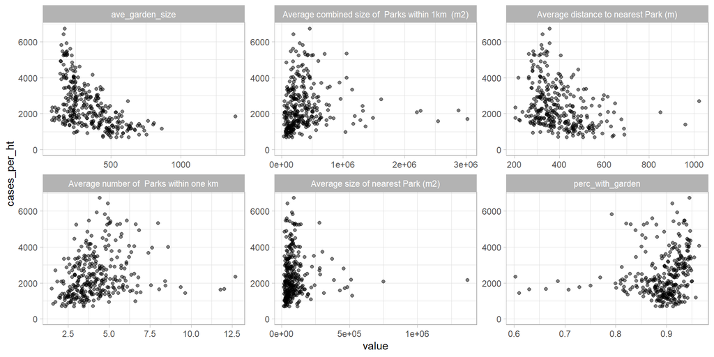

```r
total_cases_tidy <- total_cases %>%
  select(-address_count, -population, - total_cases, - num_parks_per_ht, - occupancy_rate) %>%
  pivot_longer(perc_with_garden:`Average combined size of  Parks within 1km  (m2)`,
               names_to = "explanatory_variable")

p1 <-  ggplot(data = total_cases_tidy,
             mapping = aes(x = value, y = cases_per_ht)
             )

p1 + geom_jitter(alpha = 0.5) +
    facet_wrap(~ explanatory_variable, scales="free")
```

From inspection of the scatter plots above, the most promising potential explanatory variables are the average garden size and the average distance to the nearest park. So, focus on these two variables in more detail.

```r
vars_of_interest <- c("ave_garden_size", "Average distance to nearest Park (m)")

total_cases_focus <- total_cases_tidy %>%
  # remove green space variables I am no longer interested in
  filter(explanatory_variable %in% vars_of_interest)


total_cases_focus
```

| areaCode | areaName | cases_per_ht | explanatory_variable | value |
| --- | --- | --- | --- | --- |
| E06000001 | Hartlepool | 4445.7256 | ave_garden_size | 183.00 |
| E06000001 | Hartlepool | 4445.7256 | Average distance to nearest Park (m) | 484.69 |
| E06000002 | Middlesbrough | 4171.5137 | ave_garden_size | 181.30 |
| E06000002 | Middlesbrough | 4171.5137 | Average distance to nearest Park (m) | 403.28 |
| E06000003 | Redcar and Cleveland | 3460.4448 | ave_garden_size | 201.90 |
| E06000003 | Redcar and Cleveland | 3460.4448 | Average distance to nearest Park (m) | 308.17 |
| E06000004 | Stockton-on-Tees | 4011.6951 | ave_garden_size | 238.00 |
| E06000004 | Stockton-on-Tees | 4011.6951 | Average distance to nearest Park (m) | 453.80 |
| E06000005 | Darlington | 3353.8384 | ave_garden_size | 219.20 |
| E06000005 | Darlington | 3353.8384 | Average distance to nearest Park (m) | 419.16 |

[output cut: 622 more lines]

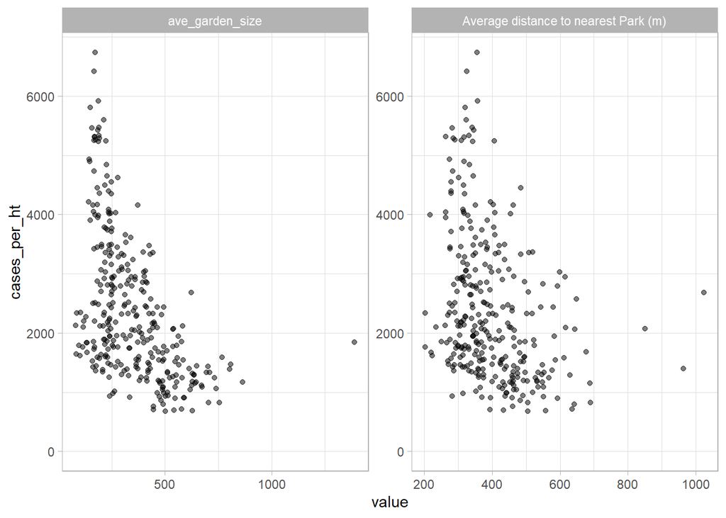

```r
p2 <-  ggplot(data = total_cases_focus,
             mapping = aes(x = value, y = cases_per_ht)
             )

p2 + geom_jitter(alpha = 0.5) +
    facet_wrap(~ explanatory_variable, scales="free")
```

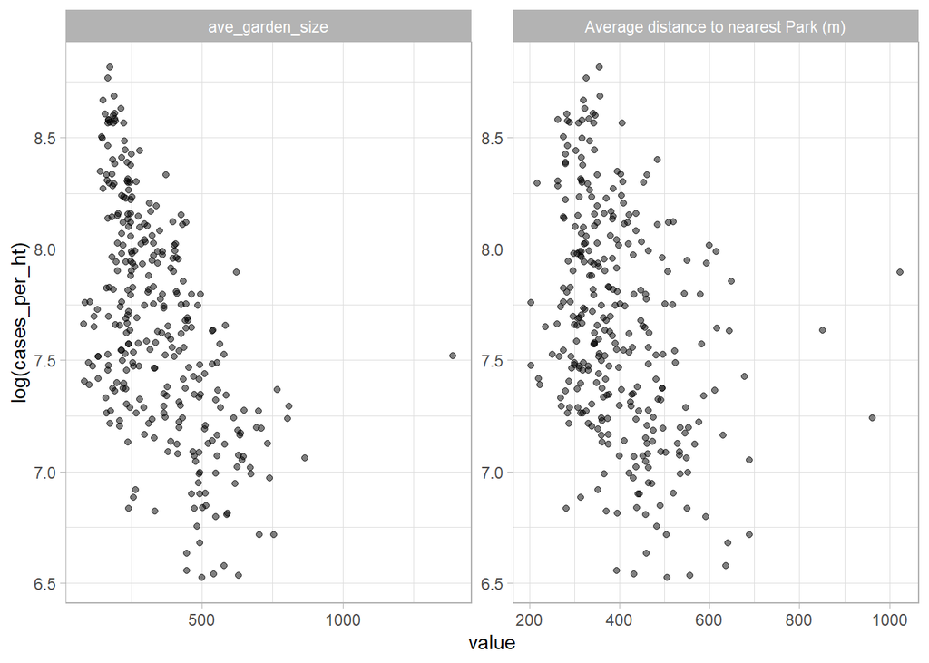

```r
p3 <-  ggplot(data = total_cases_focus,
             mapping = aes(x = value, y = log(cases_per_ht))
             )

p3 + geom_jitter(alpha = 0.5) +
    facet_wrap(~ explanatory_variable, scales="free")
```

### Exploring the role relative wealth plays in the relationship between access to green space and Covid-19 case numbers

At this point it occurred to me that it would be interesting to explore if the affluence of each Local Authority had a mediating role to play in the relationships between the two green space variables and the number of Covid-19 cases. So, I imported so some data (again from the ONS) estimating the average salaries of people living in each local authority. Within the dataset two measures of the average are provided: (1) the median salary within a given local authority; and, (2) the mean salary within a given local authority. I retained both as I had yet to make a decision on which was a more appropriate measure in the context of this analysis.

```r
income <- read_excel("./Data/PROV - Home Geography Table 8.7a   Annual pay - Gross 2020.xls",
                     sheet = "All_edit_for_import")

income <- income %>%

  # mean and median variables imported as characters (perhaps something to using read_excel ...)
  mutate(Median = as.double(Median),
         Mean = as.double(Mean)
         )
```

A bit of data wrangling was required to integrate the income data into the main dataset I am using for plotting below. Also, I need to remove some NA values that were causing problems in the plotting. I didn’t look at these NAs created by coercing the variable types from character to numeric in detail. I just filtered out Local Authority with NA values for the Mean salary later on (ahead of plotting). I also created a couple of new variables which are used later on to facet the plots.

```r
# taken from the same dataset as the Local Authority mean/median data
# these are the figures for mean/median salary for England as a whole
eng_median_salary <-  26055
eng_mean_salary <- 32237
```

```r
total_cases_income <- total_cases_focus %>%

  # add the income data to the Covid-19 case and green space data
  pivot_wider(names_from = "explanatory_variable", values_from = "value") %>%
  rename(ave_dist_to_park = "Average distance to nearest Park (m)") %>% # simplifying naming of variable of interest
  left_join(income %>%
              select(Code, Median, Mean),
            by = c("areaCode" = "Code")
            ) %>%

  #create variable to allow grouping in plots below
  mutate(above_mean = Mean > eng_mean_salary,
         above_median = Median > eng_median_salary) %>%

  # remove NAs in variables to be included in the plots
  filter(!is.na(cases_per_ht)) %>%
  filter(!is.na(Mean)) %>%
  filter(!is.na(Median))

total_cases_income
```

| areaCode | areaName | cases_per_ht | ave_garden_size | ave_dist_to_park | Median | Mean | above_mean | above_median |
| --- | --- | --- | --- | --- | --- | --- | --- | --- |
| E06000001 | Hartlepool | 4445.7256 | 183.0 | 484.69 | 22651 | 25430 | FALSE | FALSE |
| E06000002 | Middlesbrough | 4171.5137 | 181.3 | 403.28 | 22171 | 25344 | FALSE | FALSE |
| E06000003 | Redcar and Cleveland | 3460.4448 | 201.9 | 308.17 | 22015 | 26049 | FALSE | FALSE |
| E06000004 | Stockton-on-Tees | 4011.6951 | 238.0 | 453.80 | 24241 | 27778 | FALSE | FALSE |
| E06000005 | Darlington | 3353.8384 | 219.2 | 419.16 | 24634 | 28524 | FALSE | FALSE |
| E06000006 | Halton | 3764.0059 | 223.7 | 338.42 | 24067 | 29390 | FALSE | FALSE |
| E06000007 | Warrington | 4043.5400 | 235.6 | 263.14 | 24239 | 28895 | FALSE | FALSE |
| E06000008 | Blackburn with Darwen | 6732.3108 | 172.6 | 355.95 | 21221 | 23819 | FALSE | FALSE |
| E06000009 | Blackpool | 3903.3031 | 150.0 | 386.83 | 19808 | 22714 | FALSE | FALSE |
| E06000010 | Kingston upon Hull, City of | 4216.6773 | 140.7 | 395.87 | 20857 | 22626 | FALSE | FALSE |

[output cut: 275 more lines]

It took quite a lot of experimentation to find the solution to using a specified midpoint from which the colours diverge. For example, it wasn’t obvious how to do this using scale_fill_brewer or if it was even possible …

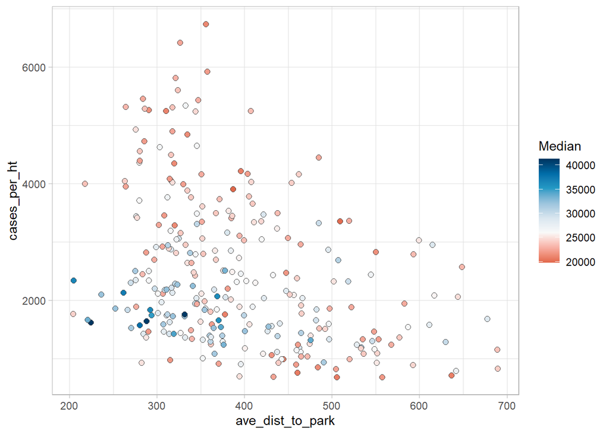

```r
green_space_covid_plotter <- function(df, x_var, sal_ave, facet_var = NULL, facet_labs = NULL){

  # set the midpoint of the diverging colour scale to either England's median or mean salary
  # strengthen the starting colour for the lower half of scale
  # (as the salary range above the mean is wider than the salary range below)

  if (sal_ave == "Median")
    colour_pallette <- scale_fill_continuous_divergingx(palette = 'RdBu',
                                        mid = eng_median_salary,
                                        c1 = 0, l1 = 0, p1 = 1, p2 = 1)
  else
    colour_pallette <- scale_fill_continuous_divergingx(palette = 'RdBu',
                                        mid = eng_mean_salary,
                                        c1 = 0, l1 = 0, p1 = 1, p2 = 1)


  # provide the option not to facet the plot
  if(is.null(facet_var)) facet = NULL

  else
    facet = facet_wrap(vars(.data[[facet_var]]), labeller = as_labeller(facet_labs))

  # create the plot
  ggplot(data = df,
             mapping = aes(x = .data[[x_var]],
                           y = cases_per_ht,
                           fill = .data[[sal_ave]])
             ) +

  geom_jitter(size = 2, shape = 21, colour = "grey30") +

  colour_pallette +

  facet

}

p_park <- green_space_covid_plotter(df = subset(total_cases_income,
                                            subset = ave_dist_to_park < 800), # remove an outlier
                                x_var = "ave_dist_to_park",
                                sal_ave = "Median"
                          )

p_garden <- green_space_covid_plotter(df = subset(total_cases_income,
                                      subset = ave_garden_size < 1000
                                      ), # remove an outlier
                          x_var = "ave_garden_size",
                          sal_ave = "Median"
                          )

p_park
```

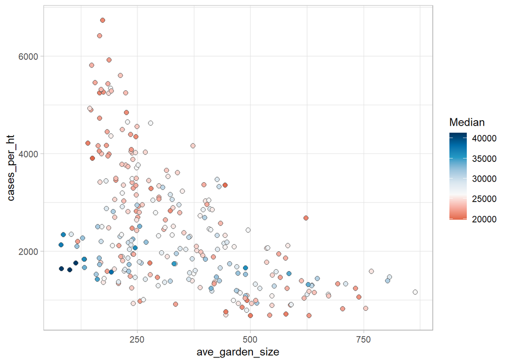

```r
p_garden
```

Mean versus median

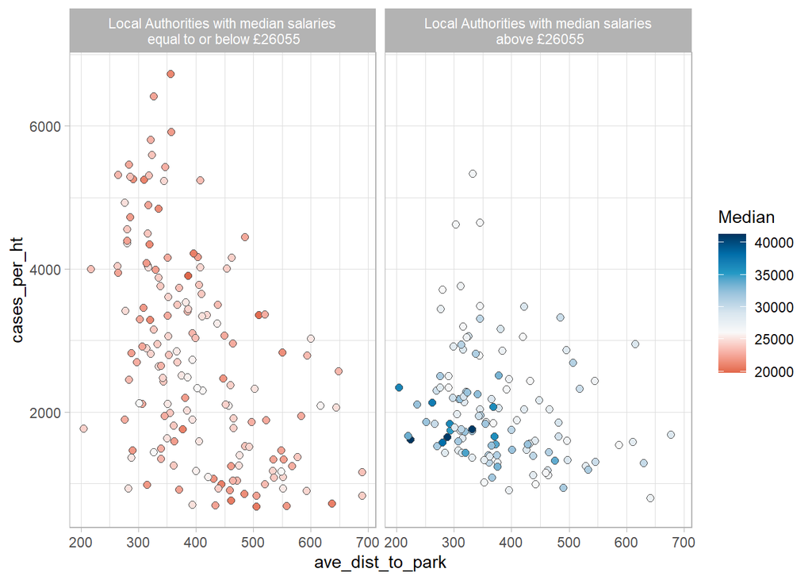

```r
# define labels for plot facets
facet_labels_mean <- c(`FALSE` = str_c("Local Authorities with mean salaries\n equal to or below £", eng_mean_salary),
                      `TRUE` = str_c("Local Authorities with mean salaries\n above £", eng_mean_salary))

facet_labels_median <- c(`FALSE` = str_c("Local Authorities with median salaries\n equal to or below £", eng_median_salary),
                      `TRUE` = str_c("Local Authorities with median salaries\n above £", eng_median_salary))



p_park_median <- green_space_covid_plotter(df = subset(total_cases_income,
                                            subset = ave_dist_to_park < 800), # remove an outlier
                                x_var = "ave_dist_to_park",
                                sal_ave = "Median",
                                facet_var = "above_median",
                                facet_labs = facet_labels_median
                          )

p_garden_median <- green_space_covid_plotter(df = subset(total_cases_income,
                                      subset = ave_garden_size < 1000
                                      ), # remove an outlier
                          x_var = "ave_garden_size",
                          sal_ave = "Median",
                          facet_var = "above_median",
                          facet_labs = facet_labels_median
                          )

p_park_mean <- green_space_covid_plotter(df = subset(total_cases_income,
                                            subset = ave_dist_to_park < 800), # remove an outlier
                                x_var = "ave_dist_to_park",
                                sal_ave = "Mean",
                                facet_var = "above_mean",
                                facet_labs = facet_labels_mean
                          )

p_garden_mean <- green_space_covid_plotter(df = subset(total_cases_income,
                                      subset = ave_garden_size < 1000
                                      ), # remove an outlier
                          x_var = "ave_garden_size",
                          sal_ave = "Mean",
                          facet_var = "above_mean",
                          facet_labs = facet_labels_mean
                          )



p_park_median
```

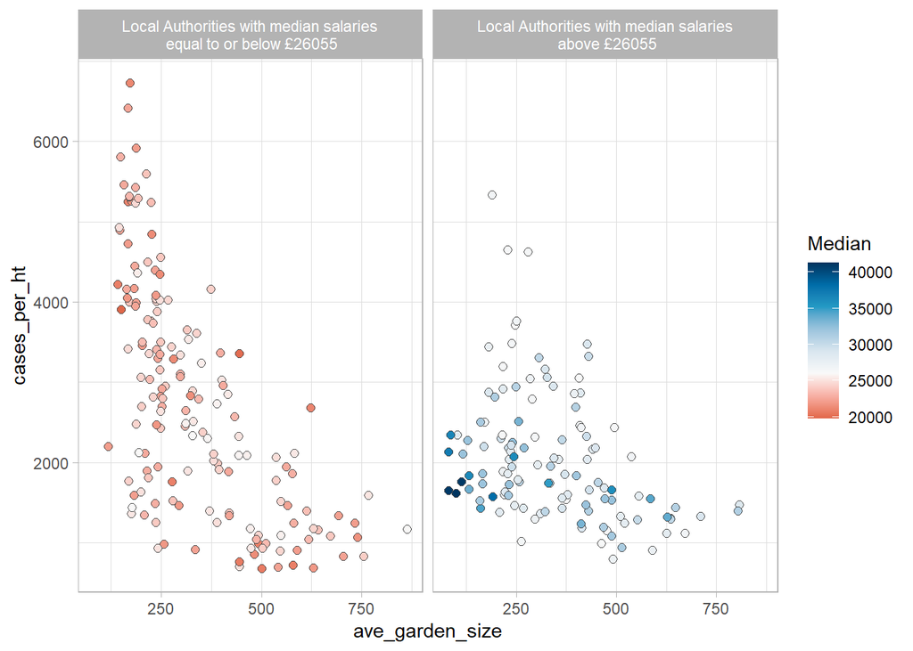

```r
p_garden_median
```

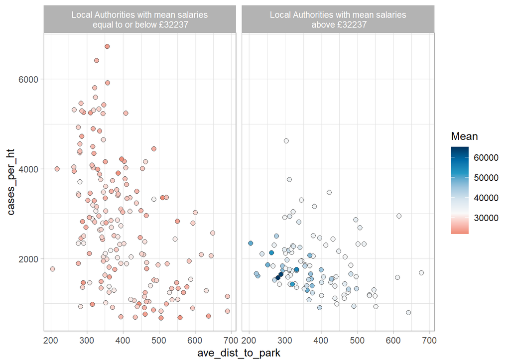

```r
p_park_mean
```

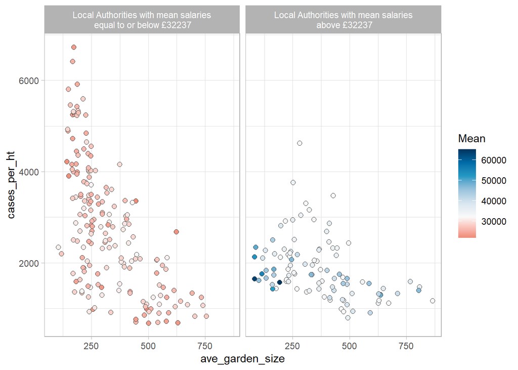

```r
p_garden_mean
```

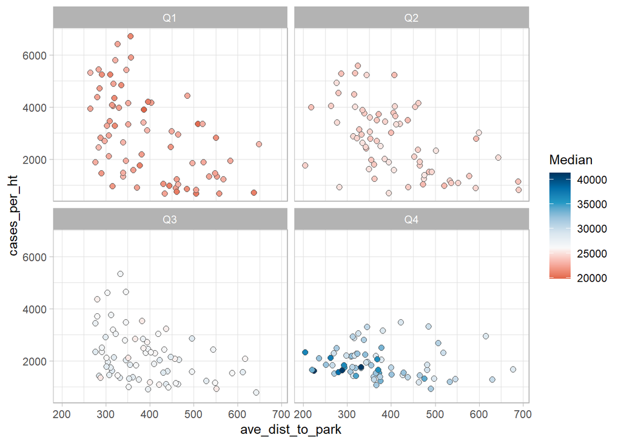

```r
# create a new variable to allow faceting by quartile
total_cases_income <- total_cases_income %>%
  mutate(median_salary_quartile = ntile(Median, 4))

# define labels for plot facets
facet_labs <-  c(`1` = "Q1", `2` = "Q2", `3` = "Q3", `4` = "Q4")


p_park_median_qs <- green_space_covid_plotter(df = subset(total_cases_income,
                                            subset = ave_dist_to_park < 800), # remove an outlier
                                x_var = "ave_dist_to_park",
                                sal_ave = "Median",
                                facet_var = "median_salary_quartile",
                                facet_labs = facet_labs
                          )

p_garden_median_qs <- green_space_covid_plotter(df = subset(total_cases_income,
                                      subset = ave_garden_size < 1000
                                      ), # remove an outlier
                          x_var = "ave_garden_size",
                          sal_ave = "Median",
                          facet_var = "median_salary_quartile",
                          facet_labs = facet_labs
                          )

p_park_median_qs
```

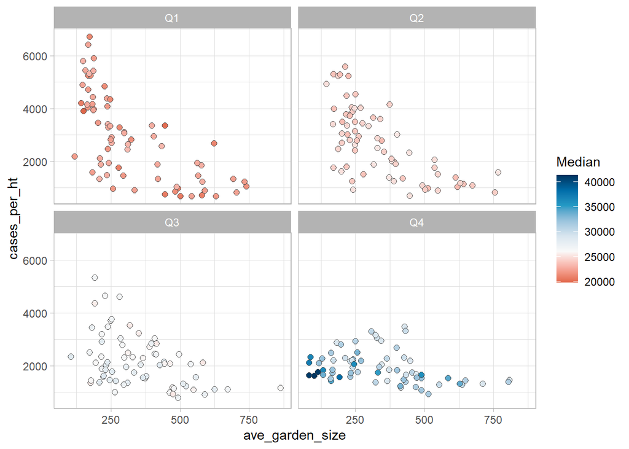

```r
p_garden_median_qs
```

Produce final plot

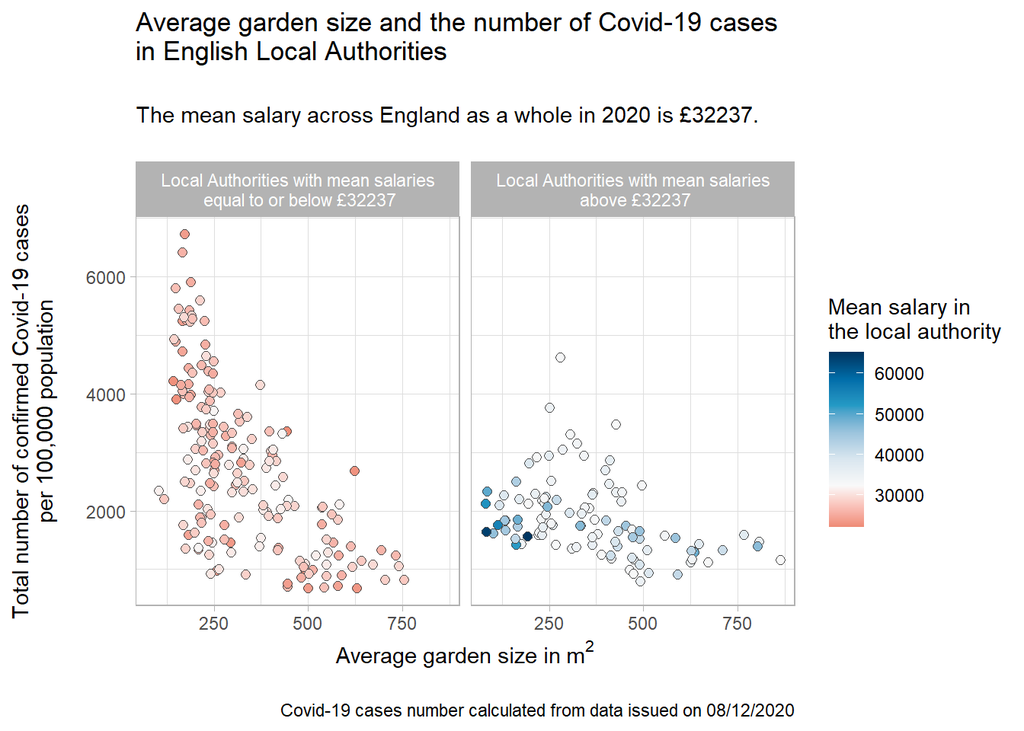

```r
data_date <- ymd(data_date)

x_label <- expression("\nAverage garden size in"~m^2)
y_label <- "Total number of confirmed Covid-19 cases\nper 100,000 population\n"
subtitle <- str_c("The mean salary across England as a whole in 2020 is £", eng_mean_salary, ".\n")
title <- "Average garden size and the number of Covid-19 cases\nin English Local Authorities\n"
legend_label <- "Mean salary in\nthe local authority"

p_garden_mean + labs(x = x_label,
         y = y_label,
         fill = legend_label,
         title = title,
         subtitle = subtitle,
         caption = str_c("\nCovid-19 cases number calculated from data issued on ", format(data_date, "%d/%m/%Y"))
         )
```

## A quick note on what I learnt in the process of producing the plots below

In the process of incorporating the income data into this exploratory data analysis. There were a couple of key areas for me to learn about:

1. how to [write functions with ggplot2](https://fishandwhistle.net/slides/rstudioconf2020/#1) that can produce plots with common features (e.g. in this case data mapped to the y axis) but with the ability to configure certain aspects plots (e.g. in the case the data mapped to the x axis). It was particularly useful to learn about how adding NULL to a ggplot object is help in creating conditions within functions that produce plots.
2. how to use colour scales for continuous variable. More specifically, [how to set midpoints when using diverging colour scales](https://stackoverflow.com/questions/58718527/setting-midpoint-for-continuous-diverging-color-scale-on-a-heatmap).
3. how to iteratively refactor code throughout the process of create a number of similar plots.